# Repaso del segundo parcial

Capítulos 4, 5 y 6 · Argentina, 1955–1989

Sebastian Freille

Universidad Nacional de Córdoba

## El recorrido del parcial

| Capítulo | Período | Pregunta para organizar el estudio |
| --- | --- | --- |
| **4. Liberalización después del peronismo** | 1955–1963 | ¿Cómo combinar estabilización, exportaciones e industrialización? |
| **5. La década de expansión** | 1963–1973 | ¿Por qué creció la economía y por qué ese crecimiento no aseguró estabilidad política ni de precios? |
| **6. Estancamiento y declinación** | 1973–1989 | ¿Cómo se pasó de la concertación a la crisis financiera, la deuda y la hiperinflación? |

El repaso incluye **Libertadora, Frondizi, Guido, Illia, Revolución Argentina, retorno del peronismo, dictadura y Alfonsín completo**.

Alcance: Programa de Historia Económica Argentina, 2024, capítulos 4–6, pp. 3–5.

## El hilo conductor: sostener una expansión

- **Crecer exige recursos:** inversión, capacidad productiva e importaciones. ¿De dónde salen las divisas?
- **Distribuir exige acuerdos:** salarios, ganancias, ingresos del agro y recursos públicos compiten sobre un producto que no crece siempre al mismo ritmo.
- **Estabilizar exige continuidad:** coordinar precios hoy y sostener mañana las cuentas fiscales, externas y financieras.

> La pregunta común es por qué tantas mejoras iniciales no se consolidaron. La respuesta cambia según la estructura productiva, el financiamiento disponible y la capacidad política de sostener acuerdos.

Síntesis del repaso a partir de las clases y Gerchunoff y Llach (2007), caps. 6–9. Es un eje interpretativo, no una causa única.

## Un mapa de cambios, no una crisis permanente

| Etapa | Transformación | Límite que reaparece |
| --- | --- | --- |
| **1955–1963** | Reforma bancaria e inversión en industrias básicas | Divisas y costos del ajuste |
| **1963–1973** | Mayor capacidad industrial y exportadora | Distribución, precios relativos y fragilidad política |
| **1973–1976** | Concertación y expansión del mercado interno | Presiones inflacionarias y ruptura del acuerdo |
| **1976–1983** | Apertura financiera y comercial | Bancos, dólar y endeudamiento |
| **1983–1989** | Democracia e intentos de estabilización | Transferencia externa, déficit e inercia |

**Continuidad:** dificultad de sostener compromisos. **Ruptura:** el crédito externo primero permite postergar ajustes y después impone nuevos pagos.

Clases de capítulos 4–6; Gerchunoff y Llach (2007), caps. 6–9.

## C4 · La Libertadora: qué recibe y qué cambia

- El golpe de **1955** interrumpe un gobierno que había reducido la inflación desde 1952. La recuperación volvía a presionar las importaciones y las reservas.
- El gobierno provisional busca revertir instituciones del peronismo, mejorar incentivos al agro y reabrir el financiamiento internacional.
- La proscripción del peronismo y el conflicto sindical reducen las posibilidades de construir un acuerdo distributivo duradero.

> El punto de partida combina una estabilización previa con dificultades externas renovadas. Derrocar al gobierno y corregir los desequilibrios económicos son procesos distintos.

Godino, «La Revolución Libertadora», diap. 4–6; Gerchunoff y Llach (2007), cap. 6.

## C4 · Prebisch: estabilización y desarrollo

| Diagnóstico | Propuesta | Mecanismo esperado |
| --- | --- | --- |
| **Inflación y financiamiento monetario** | Contener déficit, crédito y aumentos nominales | Moderar la creación de dinero y el gasto |
| **Exportaciones insuficientes** | Devaluación, mejores precios al agro, liquidación del IAPI | Ampliar oferta exportable y capacidad de importar |
| **Cuellos de botella** | Energía, transporte, acero, técnica agropecuaria y capital externo | Aumentar productividad y capacidad productiva |

La aplicación fue **parcial y desigual**. La agenda de desarrollo avanzó menos que la corrección de precios y la liberalización.

Godino, «La Revolución Libertadora», diap. 7–12; Gerchunoff y Llach y Eshag–Thorp, según la clase.

## C4 · Devaluar no asegura exportar más enseguida

1. La devaluación mejora el ingreso en pesos de los exportadores, pero también encarece alimentos e insumos.
2. Los trabajadores buscan recuperar poder de compra. Las compensaciones salariales y los costos erosionan parte de la mejora cambiaria.
3. La producción agropecuaria responde con demoras: inversión, tecnología y ciclo ganadero importan.
4. Términos del intercambio desfavorables y malas cosechas limitan el ingreso de divisas.

> La corrección de precios relativos puede ser rápida. La respuesta de cantidades lleva tiempo y puede resultar insuficiente.

Godino, «La Revolución Libertadora», diap. 13–18 y 30–33; Eshag y Thorp (1965), lectura de la clase.

## C4 · La reforma bancaria de 1957

| Dimensión | Sistema de depósitos centralizados | Reforma de 1957 |
| --- | --- | --- |
| **Captación** | Bancos reciben por cuenta del BCRA | Bancos reciben por cuenta propia |
| **Crédito** | Depende de redescuentos y directivas | Mayor vínculo con depósitos y encajes |
| **Control monetario** | Asignación centralizada | Efectivos mínimos y límites al financiamiento |
| **Balance heredado** | Deudas de organismos con el BCRA | Traspasos al Tesoro y saneamiento contable |

La reforma cambia **reglas y balances**. No elimina por sí sola los déficits futuros de las empresas públicas ni el conflicto por salarios y tarifas.

Godino, «La Revolución Libertadora», diap. 19–29. El BCRA permanece estatal.

## C4 · Balance de 1955–1958

- **Cambios institucionales:** descentralización bancaria, ingreso al FMI y Banco Mundial en 1956 y negociación con acreedores.
- **Resultados limitados:** persisten la escasez de divisas y las presiones inflacionarias. Las tarifas rezagadas complican a las empresas públicas.
- **Continuidad con 1952:** preocupación por exportaciones, productividad y estabilización.
- **Diferencia:** la Libertadora transforma la arquitectura financiera, pero no consigue sostener la coordinación fiscal y salarial.

> Reformar instituciones y estabilizar los flujos de gasto y financiamiento son tareas relacionadas, pero distintas.

Godino, «La Revolución Libertadora», diap. 30–35. El año 1958 incluye también la gestión de Frondizi.

## C4 · Frondizi: cambiar la estructura productiva

- El desarrollismo interpreta la restricción externa como un problema de **estructura**: faltan energía, insumos básicos y capacidad industrial.
- La prioridad pasa a petróleo, siderurgia, petroquímica y ramas de bienes durables.
- El capital extranjero aporta recursos, tecnología y equipos para acelerar esa transformación.
- El Estado selecciona prioridades y ofrece incentivos. La apertura al capital convive con promoción y protección industrial.

> Sustituir importaciones de hoy exige importar equipos hoy. El ahorro de divisas esperado llega después de la inversión inicial.

Clase «Frondizi y el desarrollismo», bloques 1–3; Gerchunoff y Llach (2007), cap. 6.

## C4 · Desarrollo y estabilización en 1959

| Horizonte | Objetivo | Instrumentos |
| --- | --- | --- |
| **Transformación productiva** | Reducir cuellos de botella | Contratos petroleros, inversión extranjera y promoción industrial |
| **Emergencia macroeconómica** | Frenar pérdida de reservas e inflación | Devaluación, liberalización cambiaria, ajuste fiscal y restricción crediticia |

- El viraje sigue a medidas iniciales expansivas de 1958.
- El acuerdo con el FMI aporta financiamiento condicionado a metas de estabilización.
- El ajuste de 1959 reduce actividad y salario real mientras la devaluación eleva inicialmente los precios.

Clases «Frondizi» y «Programas de estabilización del FMI»; Gerchunoff y Llach (2007), cap. 6; Eshag y Thorp (1965).

## C4 · El ajuste: dos lecturas del mismo mecanismo

| Pregunta | Lógica del programa | Crítica de Eshag y Thorp |
| --- | --- | --- |
| **¿Cómo recuperar divisas?** | Devaluar y contener demanda de importaciones | La oferta exportable responde lentamente |
| **¿Cómo frenar precios?** | Limitar déficit, dinero y crédito | La devaluación y los insumos importados elevan costos |
| **¿Qué hace la restricción crediticia?** | Reduce gasto y presión externa | También restringe producción y empleo |
| **¿Qué deja la recesión?** | Menores importaciones y alivio externo | No asegura una transformación exportadora |

La discusión exige separar **alivio inmediato**, **costo distributivo** y **sostenibilidad posterior**.

Clase «Programas de estabilización del FMI», bloques 1–2 y 4. La crítica se atribuye a Eshag y Thorp (1965).

## C4 · Hubo transformación industrial

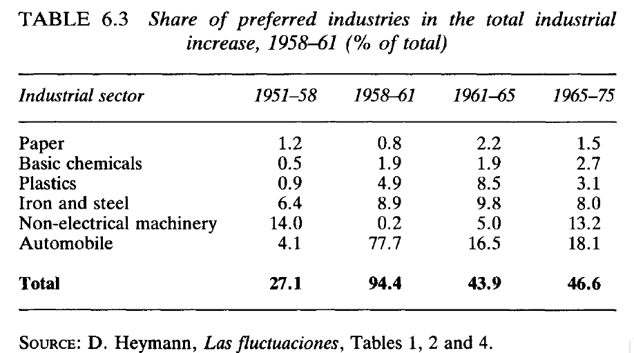

La expansión de ramas promovidas y de la producción petrolera amplió capacidades. **La crisis macroeconómica no borra esa inversión**, ni la inversión demuestra que el programa fuera sostenible.

Clase «Frondizi», bloque 3, figura original uni4_des06; Heymann, reproducido en Gerchunoff y Llach (2007), cap. 6.

## C4 · La crisis de 1962–1963

- La recuperación demanda importaciones. La inflación acumulada erosiona el tipo de cambio real y aparecen nuevas presiones sobre las reservas.
- La inestabilidad política y la interrupción del financiamiento externo agravan la vulnerabilidad. Frondizi cae en marzo de 1962.
- Bajo **Guido**, la devaluación y la contracción del crédito coinciden con dificultades de pagos y caída de la producción.
- La recesión reduce importaciones, pero los costos y la desconfianza en el peso mantienen la inflación.

> La combinación de recesión e inflación muestra por qué contraer la demanda no garantizaba una desinflación inmediata.

Clases «Frondizi» y «La década de expansión: Guido e Illia», bloque 1. Se distingue la caída política de Frondizi del ajuste posterior.

## C4 · Qué cambió entre 1955 y 1963

| Gobierno | Apuesta | Avance | Límite |
| --- | --- | --- | --- |
| **Libertadora** | Incentivos al agro y reforma institucional | Reinserción financiera y sistema bancario | Respuesta exportadora y coordinación nominal insuficientes |
| **Frondizi** | Inversión en sectores básicos | Petróleo y capacidad industrial | Divisas durante la transición y fragilidad política |
| **Guido** | Ajuste ante la crisis | Compresión de importaciones | Recesión, crédito e inflación persistente |

**Herencia para 1963:** capacidad instalada nueva, capacidad ociosa y precios relativos modificados. Esas condiciones ayudan a entender la recuperación siguiente.

Síntesis de las clases del capítulo 4 y del bloque Guido de la clase siguiente.

## C5 · Por qué 1963–1973 fue una expansión

- La inversión previa amplía la capacidad industrial y energética.
- La recuperación utiliza capacidad ociosa, con margen para producir más antes de nuevas inversiones.
- La mecanización y otras mejoras agropecuarias ayudan a ampliar la oferta exportable.
- El contexto internacional y la diversificación de exportaciones contribuyen a aliviar la restricción externa.

> La década combina crecimiento y cambios productivos con inflación y conflictos. El *stop and go* pierde intensidad, pero sus mecanismos no desaparecen para siempre.

Clases «Guido e Illia» y «Krieger Vasena», bloque 3; Gerchunoff y Llach (2007), cap. 7.

## C5 · Illia: reactivación con margen externo

| Política o condición | Canal de expansión | Condición para sostenerlo |
| --- | --- | --- |
| **Salarios, crédito y gasto** | Recuperación de la demanda | Capacidad disponible e insumos |
| **Ajustes cambiarios graduales** | Evitar una apreciación acumulada excesiva | Coordinación con precios internos |
| **Mejora agropecuaria** | Más divisas para importar | Producción y mercados externos |
| **Capacidad heredada** | Respuesta industrial a la demanda | Financiamiento y utilización efectiva |

La expansión no puede atribuirse sólo al estímulo de demanda: **importa el punto de partida**.

Clase «La década de expansión: Guido e Illia», bloques 3–4; Gerchunoff y Llach (2007), cap. 7.

## C5 · Illia: crecimiento y fragilidad política

- El gobierno combina intervención sobre ingresos y mercados con la anulación de los contratos petroleros de Frondizi.
- La recuperación económica convive con conflictos sindicales, empresariales y militares.
- La proscripción del peronismo condiciona la representación política y la construcción de acuerdos.
- El golpe de **1966** interrumpe un gobierno durante una etapa de expansión.

> Un buen resultado del producto no garantiza continuidad institucional. Tampoco la caída de un gobierno demuestra, por sí sola, el fracaso de todas sus políticas económicas.

Clase «Guido e Illia», bloques 2–4; Gerchunoff y Llach (2007), cap. 7.

## C5 · Onganía y la coordinación autoritaria

- La Revolución Argentina pretende ordenar primero la economía y postergar la competencia política y las demandas distributivas.
- Con **Krieger Vasena, desde 1967**, combina corrección inicial de precios relativos, dólar fijo y política de ingresos.
- El programa incluye mejora fiscal, inversión pública y crédito. Su funcionamiento excede una simple contracción monetaria.
- La restricción de la negociación sindical vuelve asimétrico el reparto de los costos.

> Posponer institucionalmente el conflicto no elimina los efectos distributivos de estabilizar.

Clase «La Revolución Argentina y Krieger Vasena», bloques 1–2; Gerchunoff y Llach (2007), cap. 7; De Pablo (1975).

## C5 · La devaluación compensada

| Instrumento | Función |
| --- | --- |
| **Devaluación inicial** | Reacomodar la paridad y crear margen externo |
| **Retenciones a exportaciones** | Limitar el traslado al ingreso exportador y recaudar |
| **Rebajas arancelarias** | Amortiguar el encarecimiento de importaciones |
| **Dólar fijo posterior** | Dar una referencia nominal a precios y expectativas |
| **Acuerdos de precios y salarios** | Contener la propagación de la corrección inicial |

Con precio externo constante, el ingreso exportador depende de **e × (1 − retención)**. El precio importado depende de **e × (1 + arancel)**.

Clase «Krieger Vasena», bloque 2; De Pablo (1975), pp. 64–69. Efectos diferenciados por producto.

## C5 · Desinflación con crecimiento

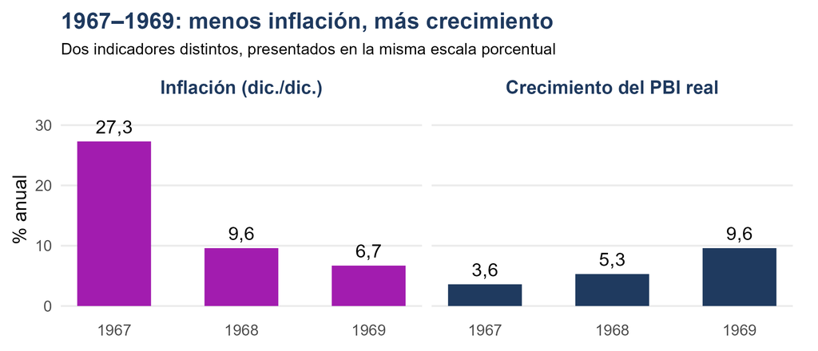

**Crédito, remonetización, inversión y alivio externo** permiten entender por qué esta estabilización no comienza con una recesión.

Figura de la clase 22. Inflación diciembre/diciembre: De Pablo (1975), cuadro 1. PBI: Gerchunoff y Llach (2007), p. 327. Series de fuentes diferentes.

## C5 · Distribución: cuatro resultados distintos

| Indicador | Qué permite afirmar | Qué no permite inferir solo |
| --- | --- | --- |
| **Producto** | Cuánto produce la economía | Cómo se reparte el ingreso |
| **Empleo** | Cuántas personas trabajan | Cuánto compra cada salario |
| **Salario real** | Poder de compra de la remuneración | Participación del trabajo en el ingreso |
| **Participación salarial** | Peso de la masa salarial en el total | Distribución entre todos los hogares |

El programa afecta de manera distinta a trabajadores, agro, industria, acreedores y deudores. **El año base también cambia la comparación**.

Clase «Krieger Vasena», bloque 3; De Pablo (1975), cuadros 5–6.

## C5 · Los límites económicos de las anclas

- **Dólar fijo:** la inflación residual aprecia la moneda y reduce el margen externo inicial.
- **Carne:** la liquidación de hacienda puede contener precios hoy y reducir la oferta futura.
- **Crédito:** si baja la inflación más que la tasa nominal, sube la tasa real y se encarece la deuda.
- **Congelamientos:** corregir salarios o precios rezagados exige modificar las pautas que habían coordinado expectativas.

> De Pablo señala problemas de diseño incluso antes de atribuir la ruptura a la política: faltaba una transición sostenible desde las anclas iniciales.

Clase «Krieger Vasena», bloque 4; De Pablo (1975), pp. 73–82.

## C5 · Cordobazo y salida de la Revolución Argentina

| Momento | Cambio político | Trayectoria económica |
| --- | --- | --- |
| **1969** | Cordobazo y salida de Krieger Vasena | Dagnino Pastore conserva elementos del esquema |
| **1970–1971** | Caída de Onganía y gobierno de Levingston | Devaluación y giro nacional desarrollista |
| **1971–1973** | Lanusse y negociación de la salida electoral | Más inflación y debilitamiento de la conducción |

El quiebre político y los problemas de precios relativos **se refuerzan**. La gestión del ministro termina en 1969, pero partes del programa continúan hasta 1970.

Clase «Krieger Vasena», bloque 4; Gerchunoff y Llach (2007), pp. 328–331; De Pablo (1975).

## C5 · Illia y Krieger Vasena, en contraste

| Dimensión | Illia | Krieger Vasena |
| --- | --- | --- |
| **Marco político** | Gobierno electo con proscripciones | Dictadura y negociación restringida |
| **Demanda** | Reactivación y recuperación de ingresos | Inversión, crédito y desinflación |
| **Cambio** | Ajustes graduales | Corrección inicial y fijación posterior |
| **Distribución** | Recomposición salarial | Coordinación administrada y costos asimétricos |
| **Límite** | Fragilidad institucional pese al crecimiento | Conflicto político y rigidez de precios relativos |

Ambos actúan sobre una **economía con capacidades en expansión**. Difieren sus instrumentos y las bases políticas para sostenerlos.

Síntesis de las clases del capítulo 5; Gerchunoff y Llach (2007), cap. 7.

## C6 · 1973: una oportunidad y varias tensiones

- El retorno del peronismo recibe una economía que había crecido durante una década, con inflación ascendente.
- La coyuntura externa favorable amplía inicialmente las divisas disponibles.
- Gelbard busca combinar mercado interno, redistribución, inversión y expansión exportadora mediante mayor intervención estatal.
- El **Pacto Social** intenta coordinar a gobierno, sindicatos y empresarios. La autoridad de Perón sostiene el arbitraje.

> La concertación cambia la base política de la estabilización, pero también debe resolver cómo repartir los costos cuando cambian las condiciones.

Clase «Retorno del peronismo y Pacto Social», bloques 1 y 3; Gerchunoff y Llach (2007), cap. 8.

## C6 · Depósitos y crédito en 1973

- Los bancos vuelven a recibir depósitos por cuenta del BCRA y el crédito se organiza mediante redescuentos.
- El objetivo es orientar recursos hacia prioridades productivas y distributivas.
- Las tasas reguladas bajas abaratan préstamos para quienes acceden, pero con inflación desalientan mantener ahorros en el circuito formal.
- Otros instrumentos y circuitos financieros limitan el alcance efectivo de los controles.

> Centralizar formalmente los depósitos no asegura controlar todas las operaciones. La reforma de 1973 tampoco reproduce sin cambios la experiencia de 1946.

Clase «Retorno del peronismo», bloque 2; Arnaudo (1986), cap. 6, pp. 97–103 en el programa.

## C6 · Pacto Social: medidas y éxito inicial

| Medida | Objetivo |
| --- | --- |
| **Aumento salarial inicial de suma fija** | Recuperar ingresos y favorecer proporcionalmente a salarios bajos |
| **Congelamiento de precios y pautas salariales** | Interrumpir remarcaciones y compensaciones sucesivas |
| **Tarifas ajustadas inicialmente y luego contenidas** | Coordinar costos públicos y privados |
| **Estabilidad cambiaria y crédito** | Sostener expectativas, actividad y mayores remuneraciones |

La inflación se frena y mejora el poder de compra. Al aumentar la **demanda de pesos**, la remonetización absorbe parte de la expansión de dinero.

Clase «Pacto Social», bloque 3; Arnaudo (1979), pp. 30–37; Gerchunoff y Llach (2007), pp. 343–345.

## C6 · Propagación y presiones inflacionarias

| Problema | Por qué el congelamiento no basta |
| --- | --- |
| **Propagación** | Puede frenar la sucesión de remarcaciones y compensaciones |
| **Demanda** | El gasto puede crecer más que la oferta disponible |
| **Costos externos** | Los insumos importados pueden encarecerse igualmente |
| **Precios relativos** | El punto de partida conserva márgenes y rezagos diferentes |
| **Financiamiento público** | Subsidios y tarifas contenidas requieren recursos |

**Arnaudo:** interrumpir la propagación puede funcionar al comienzo. Consolidarlo exige atender las presiones y revisar los precios relativos.

Clase «Pacto Social», bloques 3–4; Arnaudo (1979), pp. 31–44.

## C6 · La ruptura de 1974–1975

1. El shock de insumos y energía eleva costos mientras los precios finales siguen controlados.
2. La expansión aumenta la presión de demanda. Aparecen problemas de márgenes, abastecimiento y revisiones salariales.
3. El deterioro externo y la muerte de Perón en 1974 debilitan simultáneamente recursos y arbitraje político.
4. Gómez Morales intenta correcciones graduales, con poco margen para sostenerlas.

> Si sube un costo real, alguien debe absorberlo: empresas, trabajadores, consumidores o Estado. Compensar a todos nominalmente puede reabrir la inflación.

Clase «Pacto Social», bloque 4; Arnaudo (1979), pp. 35–48; Gerchunoff y Llach (2007), pp. 346–349.

## C6 · El Rodrigazo y el cambio de dinámica

- En **junio de 1975**, una fuerte corrección del dólar y las tarifas modifica precios relativos y reduce inicialmente el salario real.
- La resistencia sindical fuerza nuevas negociaciones. Las compensaciones y los traslados a precios impiden consolidar el ajuste.
- La concentración de paritarias acelera la comparación entre convenios y las demandas de recomposición.
- Con las posteriores reglas de actualización, la inflación pasada adquiere mayor peso en los ajustes futuros.

> Un salto de precios relativos puede ocurrir una vez. La inflación persistente exige explicar cómo se repiten, propagan y financian los aumentos.

Clase «Pacto Social», cierre del bloque 4; Arnaudo (1979), pp. 48–52; Gerchunoff y Llach (2007), pp. 348–350.

## C6 · 1976: proyecto económico y poder político

- La dictadura recibe inflación acelerada, dificultades fiscales y escasez de divisas.
- La represión y la intervención sindical reducen la capacidad de negociación de los trabajadores.
- Martínez de Hoz propone estabilizar y modificar la asignación de recursos mediante reformas financieras y apertura.
- Persisten empresas públicas, gastos y garantías estatales. La liberalización convive con intervenciones decisivas.

> Canitrot interpreta la apertura también como una herramienta de disciplinamiento social. La crisis heredada no determina automáticamente las políticas elegidas.

Clase «El Proceso», bloque 1; Gerchunoff y Llach (2007), cap. 8; Canitrot (1981), interpretación discutida en clase.

## C6 · La reforma financiera de 1977

| Cambio | Promesa | Riesgo |
| --- | --- | --- |
| **Depósitos descentralizados** | Captar recursos para prestar | Competir por fondos sin evaluar solvencia |
| **Mayor libertad de tasas** | Remunerar ahorro y seleccionar inversiones | Tasas reales difíciles de afrontar |
| **Expansión bancaria** | Más intermediación | Créditos riesgosos o vinculados |
| **Amplias garantías** | Proteger depósitos y confianza | Menor vigilancia si la supervisión es insuficiente |

Más depósitos bancarios pueden reflejar **cambios de cartera**. No equivalen necesariamente a más ahorro nacional ni a mejor inversión.

Clase «El Proceso», bloque 2; Gerchunoff y Llach (2007), pp. 358–363.

## C6 · Apertura comercial y apertura financiera

| Apertura | Mecanismo | Interacción con el dólar |
| --- | --- | --- |
| **Comercial** | Rebajas arancelarias y mayor competencia importada | La apreciación abarata importaciones adicionalmente |
| **Financiera** | Mayor acceso a préstamos y movimientos de capital | Las entradas pueden sostener reservas y gasto |

- Si el arancel inicial era redundante, una rebaja puede no alterar de inmediato el precio local.
- Si cae suficientemente la protección efectiva y se aprecia el peso, aumenta la presión sobre la producción transable.
- El financiamiento permite sostener compras externas mientras se acumulan obligaciones futuras.

Clase «El Proceso», bloque 3; Gerchunoff y Llach (2007), pp. 363–372; Canitrot (1981).

## C6 · Varios intentos de estabilización

| Etapa | Instrumento dominante | Dificultad |
| --- | --- | --- |
| **1976** | Salarios contenidos y liberación de precios | Baja desde el pico, pero persiste inflación |
| **1977** | Tregua de precios y luego restricción monetaria | Crédito caro y caída de actividad |
| **1978** | Cambios en la intervención cambiaria | Tensión entre dinero, tasas y flujos de capital |
| **1979–1980** | Tablita anunciada en diciembre de 1978 | Inflación superior a la convergencia prevista |

Con movilidad de capitales, tasas altas pueden atraer dólares. **Comprarlos emitiendo pesos contrarresta la restricción monetaria**, salvo esterilización u otras medidas.

Clase «El Proceso», bloque 4; Gerchunoff y Llach (2007), pp. 357–367.

## C6 · La tablita: el dólar subía y quedaba atrás

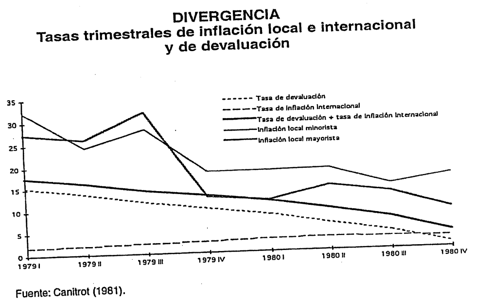

La pauta anunciaba **devaluaciones decrecientes**. La inflación interna persistente acumuló apreciación real, aunque el dólar nominal siguiera aumentando.

Clase «El Proceso», bloque 4. Gerchunoff y Llach (2007), p. 365, gráfico basado en Canitrot. Tasas trimestrales.

## C6 · Tasas, capitales y fragilidad

- Una tasa en pesos superior a la devaluación efectiva permite obtener un rendimiento positivo en dólares, antes de costos.
- Esa ganancia depende del **dólar de salida**. El riesgo de salto cambiario permanece.
- Las entradas de capital financian el desequilibrio externo, pero pueden revertirse mucho más rápido que la inversión productiva.
- La deuda en dólares de empresas con ingresos en pesos se vuelve más pesada al devaluar.

> El financiamiento puede prolongar un programa y aumentar el costo de su ruptura. El buen desempeño de un año no mide esa vulnerabilidad acumulada.

Clase «El Proceso», bloques 4–5; Gerchunoff y Llach (2007), pp. 364–377.

## C6 · Crisis bancaria y crisis cambiaria

| Problema | Respuesta posible | Nueva tensión |
| --- | --- | --- |
| **Bancos con préstamos incobrables, 1980** | Garantías y asistencia del BCRA | Costos públicos y necesidades de liquidez |
| **Salida de fondos y reservas** | Tasas altas para defender la pauta | Más dificultades de los deudores |
| **Pérdida de competitividad** | Devaluar | Mayor deuda en pesos para quienes deben dólares |
| **Ruptura de la tablita, 1981** | Nuevos regímenes cambiarios | Confianza deteriorada y nuevas salidas |

Los balances de bancos, empresas y Estado conectan ambas crisis. **Rescatar liquidez no resuelve necesariamente insolvencia**.

Clase «El Proceso», bloque 5; Gerchunoff y Llach (2007), pp. 360–361, 367 y 373–377.

## C6 · 1981–1983: deudas y pérdidas cambian de manos

- Las devaluaciones encarecen las obligaciones externas de deudores con ingresos en pesos.
- Los **seguros de cambio** y las refinanciaciones trasladan parte de ese riesgo al sector público.
- En 1982, refinanciar deudas internas a tasas inferiores a la inflación reduce su valor real y redistribuye pérdidas.
- Las tasas internacionales altas y la crisis regional de deuda restringen el nuevo crédito. Malvinas agrava las condiciones argentinas.

> Licuar una deuda en pesos y absorber una deuda en dólares son operaciones distintas. Ninguna crea por sí misma las divisas para pagar al exterior.

Clase «El Proceso», bloque 5; Gerchunoff y Llach (2007), pp. 373–379. La transferencia de deuda privada fue un proceso, no una única operación.

## C6 · La trampa de los ochenta: doble transferencia

| Transferencia | Qué exige | Por qué se complica |
| --- | --- | --- |
| **De la economía al exterior** | Divisas para pagos netos | Poco crédito, exportaciones limitadas y necesidad de importar |
| **Del sector privado al Estado** | Recursos fiscales para atender deuda pública | Recaudación débil, recesión y demandas de gasto |

- Un superávit comercial puede coexistir con déficit fiscal: los dólares exportados no pertenecen automáticamente al Tesoro.
- Comprimir importaciones ayuda a pagar hoy, pero puede reducir producción, inversión y capacidad de pago futura.

Clase «Alfonsín: primeros programas y deuda», bloque 2; Gerchunoff y Llach (2007), pp. 386–392.

## C6 · Grinspun: recuperar ingresos bajo otras restricciones

- Desde diciembre de 1983, salarios, crédito y gasto deben impulsar la recuperación mientras las pautas nominales reducen gradualmente la inflación.
- Los precios que se adelantan obligan a compensaciones salariales. La indexación pasa a reproducir inflación pasada.
- La negociación externa no obtiene el alivio suficiente. La legitimidad democrática no elimina los vencimientos.
- A fines de 1984, el acuerdo con el FMI acompaña un giro contractivo, con devaluación y tarifas. La inflación persiste con recesión.

**Contraste con Illia:** la capacidad ociosa sigue importando, pero ahora pesan una deuda mayor, menos crédito e inflación mucho más alta.

Clase «Alfonsín», bloques 1, 3 y 4; Gerchunoff y Llach (2007), pp. 393–397.

## C6 · 1985: déficit e inercia en el mismo diagnóstico

| Dimensión | Problema | Respuesta buscada |
| --- | --- | --- |
| **Fiscal y monetaria** | Financiamiento persistente del desequilibrio público | Reducir déficit y limitar su monetización |
| **Inercial** | Contratos y decisiones siguen la inflación pasada | Cortar simultáneamente las referencias nominales |
| **Expectativas** | Nadie quiere quedar rezagado frente a otros precios | Una señal coordinada y creíble |

Sourrouille reemplaza a Grinspun en febrero. El nuevo diagnóstico sostiene que **la contracción sola puede ser costosa y el congelamiento solo puede ser transitorio**.

Gerchunoff y Llach (2007), pp. 396–398; Machinea (1990), sección II.3. Continuación del capítulo 6 a partir de la bibliografía.

## C6 · El Plan Austral, junio de 1985

| Pieza | Función |
| --- | --- |
| **Correcciones previas de dólar y tarifas** | Reducir rezagos antes de fijar referencias |
| **Congelamiento de precios, salarios y cambio** | Interrumpir la coordinación sobre inflación pasada |
| **Ajuste fiscal e ingresos adicionales** | Reducir necesidad de financiamiento monetario |
| **Compromiso sobre emisión al Tesoro** | Respaldar el cambio de expectativas |
| **Nueva moneda y desagio** | Señalar el cambio y adaptar contratos preexistentes |

**1 austral = 1.000 pesos argentinos.** Cambiar la unidad monetaria acompaña al programa, pero no reemplaza sus medidas.

Gerchunoff y Llach (2007), pp. 398–399. Conversión y vigencia: BCRA, «Emisiones anteriores», austral desde el 15/6/1985.

## C6 · El desagio: una deuda pactada con inflación

- Los pagos nominales acordados antes del plan podían incorporar una inflación esperada muy elevada.
- Si los precios se frenaban abruptamente, mantener intactos esos pagos aumentaba inesperadamente su carga real.
- La tabla de conversión buscaba retirar el componente inflacionario implícito de los contratos alcanzados.

| Ejemplo ilustrativo | Importe nominal | Poder de compra del pago |
| --- | --- | --- |
| Pago futuro de 150, con precios esperados de 100 a 150 | 150 | 100 a precios iniciales |
| Mismo pago si los precios quedan en 100 | 150 | 150 a precios iniciales |

Gerchunoff y Llach (2007), p. 399. Ejemplo didáctico: no reproduce la tabla histórica ni sus reglas contractuales.

## C6 · Por qué funcionó inicialmente el Austral

- La coordinación nominal frena rápidamente las remarcaciones y reduce la inflación esperada.
- Aumenta la demanda de dinero: la **remonetización** permite absorber pesos sin un traslado proporcional a precios.
- La menor inflación reduce la pérdida real de recaudación entre el momento de devengar y cobrar impuestos: mejora el efecto **Olivera–Tanzi**.
- La recuperación del poder de compra y del crédito contribuye a la reactivación posterior.

> El éxito inicial genera recursos y respaldo. No garantiza que la mejora fiscal, las pautas y la confianza sobrevivan a nuevas tensiones.

Gerchunoff y Llach (2007), pp. 398–401. Se distingue la recesión previa a junio de la recuperación posterior.

## C6 · 1986: la salida del congelamiento

- La inflación residual acumula rezagos en salarios, tarifas y tipo de cambio.
- Mantenerlos fijos afecta ingresos laborales, cuentas públicas y competitividad.
- En **abril de 1986**, la flexibilización introduce ajustes pautados para corregir esas diferencias.
- Las demandas de recuperación y la persistencia de problemas fiscales debilitan la coordinación. Reaparecen aumentos superiores a las pautas.

> Es el problema de salida visto en 1967 y 1973: cómo permitir cambios de precios relativos sin que todos los contratos vuelvan a copiar la inflación pasada.

Gerchunoff y Llach (2007), pp. 400–405.

## C6 · 1987: nuevos intentos, menor capacidad de sostenerlos

| Momento | Medida o cambio | Límite |
| --- | --- | --- |
| **Febrero: «australito»** | Nuevo congelamiento | Déficit persistente y menores expectativas de continuidad |
| **Durante el año** | Presiones salariales, provinciales y de financiamiento | Endeudamiento interno y costos crecientes |
| **Octubre** | Otro intento con congelamiento y reformas financieras | Baja breve de inflación, sin consolidación fiscal |
| **Fin de año** | Abandono del congelamiento | Pautas desgastadas y renovada aceleración |

Las iniciativas de reforma estatal y comercial enfrentan dificultades políticas. **Repetir el instrumento no reproduce la credibilidad de 1985**.

Gerchunoff y Llach (2007), pp. 405–415. Se distinguen los intentos de febrero y octubre.

## C6 · Déficit fiscal y cuasifiscal

| Dónde aparece | Ejemplo de obligación | Efecto posible |
| --- | --- | --- |
| **Tesoro y empresas públicas** | Gastos, intereses y tarifas insuficientes | Necesidad de impuestos, crédito o emisión |
| **Banco Central** | Intereses sobre pasivos y mecanismos de absorción monetaria | Costos que pueden requerir emisión posterior |

- Esterilizar retira liquidez hoy, pero si la deuda remunerada crece sin respaldo puede elevar las necesidades futuras.
- Subir tasas para retener fondos aumenta el costo financiero y puede debilitar al deudor público.

> La consistencia debe evaluarse para el sector público en conjunto, evitando sumar dos veces operaciones entre organismos.

Gerchunoff y Llach (2007), pp. 405–417; conexión con rescates y garantías discutidos en «El Proceso».

## C6 · Plan Primavera, 1988

- **Acuerdo con empresas:** moderar aumentos sin reproducir un congelamiento universal como el de 1985.
- **Esquema cambiario:** mercados diferenciados, intervención y una trayectoria del dólar como referencia para expectativas.
- **Financiamiento:** tasas elevadas para retener fondos, refinanciación interna y búsqueda de alivio externo.
- **Resultado inicial:** baja de inflación, con reservas escasas y necesidad de sostener la confianza.

> El parecido con la tablita está en el papel del dólar y de los capitales de corto plazo. La diferencia es el contexto: deuda, crédito externo restringido y gobierno debilitado.

Gerchunoff y Llach (2007), pp. 416–418. Programa implementado en agosto de 1988.

## C6 · 1989: de la corrida a la hiperinflación

1. La desconfianza y la escasez de reservas provocan salida de fondos hacia el dólar. El esquema Primavera se rompe en febrero.
2. La depreciación acelera precios y reduce la demanda de moneda local. Los plazos de contratos y pagos se acortan.
3. Los intereses y las necesidades fiscales presionan la emisión, mientras cobrar impuestos con demora rinde cada vez menos en términos reales.
4. Remarcaciones, adelanto de compras y postergación de pagos amplifican la crisis. La transición presidencial se adelanta a julio.

> **Déficit, deuda, dólar y demanda de dinero se retroalimentan.** La inercia de la alta inflación da paso a una coordinación cada vez más inmediata alrededor del dólar.

Gerchunoff y Llach (2007), pp. 418–419. El repaso termina con la transición presidencial de julio de 1989.

## C6 · Alfonsín: cómo cambia el intento de estabilizar

| Etapa | Apuesta | Por qué pierde fuerza |
| --- | --- | --- |
| **Grinspun, 1983–1985** | Recuperación y desinflación gradual | Pautas incumplidas, indexación y restricción externa |
| **Austral, 1985** | Corrección fiscal más ruptura de la inercia | Dificultad de consolidar y flexibilizar |
| **Revisiones, 1986–1987** | Pautas y nuevos congelamientos | Déficit, presiones distributivas y desgaste |
| **Primavera, 1988** | Acuerdo empresarial y ancla cambiaria | Reservas escasas y financiamiento frágil |
| **Crisis, 1989** | Intentos de contener la corrida | Colapso de confianza y retroalimentación monetaria |

Clase «Alfonsín» y Gerchunoff y Llach (2007), cap. 9.

## Comparación · El problema externo cambia

| Etapa | Necesidad principal | Forma de alivio | Riesgo |
| --- | --- | --- | --- |
| **Industrialización** | Importar insumos y equipos | Exportar, sustituir e invertir | El ahorro de divisas tarda |
| **Expansión de los sesenta** | Sostener más producción | Capacidad exportadora y capitales | Apreciación y reversión de flujos |
| **Apertura financiera** | Financiar gasto y desequilibrios | Endeudamiento externo | Deuda y crisis de balances |
| **Después de 1982** | Atender pagos netos al exterior | Superávit comercial y renegociación | Recesión, menor inversión y tensión fiscal |

**Restricción externa** no significa siempre el mismo problema, ni se resuelve siempre con el mismo instrumento.

Síntesis de capítulos 4–6; Gerchunoff y Llach (2007), caps. 6–9.

## Comparación · El atraso cambiario como mecanismo

El tipo de cambio real es **q = e × P* / P**: e es el dólar en moneda local, P* los precios externos y P los internos. Una caída de q representa apreciación real.

| Episodio | Cómo opera | Qué lo vuelve problemático |
| --- | --- | --- |
| **Frondizi / Krieger Vasena** | Paridad relativamente estable e inflación residual | Se erosiona el margen externo |
| **Tablita** | Devaluación inferior a la inflación relativa | Apertura, importaciones y deuda amplifican efectos |
| **Austral / Primavera** | Anclas nominales con inflación persistente | Rezagos, reservas y dificultad de corregir |

La apreciación es un movimiento observable. Calificarla de **atraso insostenible** requiere mirar productividad, cuentas externas y financiamiento.

Formalización y comparación a partir de las clases Frondizi, Krieger Vasena y Proceso, y Gerchunoff y Llach (2007), cap. 9.

## Comparación · Qué anclaba cada programa

| Programa | Instrumento central | Respaldo necesario |
| --- | --- | --- |
| **1959** | Corrección cambiaria y restricción fiscal y monetaria | Divisas, inversión y continuidad política |
| **1967** | Dólar fijo y política de ingresos | Recursos fiscales y ajustes relativos sostenibles |
| **1973** | Acuerdo y congelamiento | Arbitraje político y control de las presiones |
| **1979** | Trayectoria cambiaria anunciada | Convergencia inflacionaria y solvencia financiera |
| **1985** | Congelamiento con ajuste fiscal y desindexación | Consolidación fiscal y transición a reglas flexibles |
| **1988** | Dólar y acuerdo empresarial | Reservas y financiamiento creíble |

Síntesis de clases y Gerchunoff y Llach (2007), caps. 6–9. Las filas resumen instrumentos dominantes, no programas completos.

## Comparación · Quién paga cada corrección

| Corrección | Canal distributivo | Reacción que puede desestabilizar |
| --- | --- | --- |
| **Devaluación** | Más ingreso exportador y mayores costos internos | Compensaciones y traslado a precios |
| **Tarifas** | Recursos a empresas públicas, costo al usuario | Reclamos y subsidios compensatorios |
| **Salarios contenidos** | Menor costo laboral real si suben precios | Conflicto y demanda de recomposición |
| **Tasa real alta** | Transferencia de deudores a acreedores | Incumplimientos y rescates |
| **Licuación o garantías públicas** | Alivio a deudores o depositantes | Pérdidas sobre otros ahorros o cuentas estatales |

La sostenibilidad depende de **cómo se reparten y financian las pérdidas**, además de la elección del ancla.

Comparación de Eshag–Thorp, De Pablo y Arnaudo según las clases, y Gerchunoff y Llach (2007), caps. 8–9.

## Comparación · Qué se repite y qué cambia

**Se repite**

- Alivio inicial y problemas de continuidad.
- Tensiones entre precios relativos y anclas nominales.
- Disputa por ingresos y costos del ajuste.
- Dependencia de recursos fiscales y externos.

**Cambia**

- La capacidad productiva y exportadora.
- El acceso al capital y la carga de deuda.
- El papel de bancos y balances públicos.
- El régimen político y la velocidad de la inflación.

> La inestabilidad es el resultado que buscamos explicar. Para hacerlo hay que identificar mecanismos y condiciones de cada etapa.

Síntesis interpretativa del repaso, capítulos 4–6.

## Preguntas para ensayar una respuesta de parcial

1. ¿Por qué la Libertadora pudo cambiar el régimen bancario sin estabilizar duraderamente? Comparar con el problema de Frondizi.
2. ¿Qué condiciones hicieron posible la expansión de 1963–1973? Contrastar Illia y Krieger Vasena.
3. ¿Qué diferencia hay entre frenar la propagación y eliminar presiones inflacionarias? Aplicar a 1973 y 1985.
4. ¿Cómo se conectan reforma financiera, tablita, crisis bancaria y deuda pública externa?
5. ¿Por qué el problema de Alfonsín no se resolvía sólo con superávit comercial? Explicar la trayectoria hasta 1989.

**Una respuesta completa:** punto de partida, instrumento, mecanismo, resultado y límite. Las comparaciones necesitan explicar diferencias, además de señalar semejanzas.

Preguntas de práctica elaboradas para cubrir los objetivos del Programa 2024. No son predicciones del examen.

## Fuentes y recorrido de lectura

- **Capítulo 4:** Godino, *La Revolución Libertadora* (PDF de clase). Clases *Frondizi*, *Programas del FMI* y bloque *Guido*. Gerchunoff–Llach, cap. 6, y Eshag–Thorp (1965).
- **Capítulo 5:** clases *Guido e Illia* y *Krieger Vasena*. Gerchunoff–Llach, cap. 7, y De Pablo (1975), estudio de **1967–1970**.
- **Capítulo 6:** clases *Retorno del peronismo*, *El Proceso* y *Alfonsín*. Arnaudo (1979 y 1986), Canitrot (1981) y Gerchunoff–Llach, caps. 8–9.
- **Para 1985–1989:** Gerchunoff–Llach (2007), pp. 396–419, completa las clases disponibles. Machinea (1990), sección II.3, para el diagnóstico del Austral.

Programa 2024 y bibliografía de las clases. Verificación de la moneda: [BCRA, emisiones anteriores](https://www.bcra.gob.ar/billetes-y-monedas-emisiones-anteriores/). Las fuentes específicas figuran en cada diapositiva.